# A long-context hybrid baseline on eight stocks

## 2. How long can the context actually be?

Two separate walls, and they sit in different places.

**Generation is not the binding one.** A 4,000-message forward pass is 21.15 GB, a quarter of one GH200. **Training is.** Backward memory grows linearly at 35.24 GB per thousand messages, and the fit was built on three clean points (500 / 1,000 / 1,500) with a measured OOM at 1,750 confirming it.

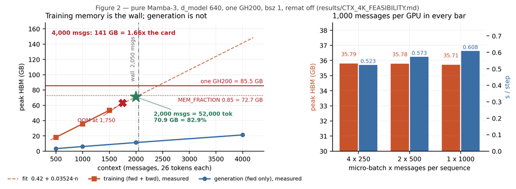

Figure 2 · 94 KB

```
arithmetic wall at MEM_FRACTION 0.85 : 2,050 messages (53,310 tokens)
projected peak at 2,000 messages     : 70.9 GB (82.9% of the card)
projected peak at 4,000 messages     : 141.4 GB linear, 134 GB with the measured sublinear correction
```

```python
ms = M["memory_scaling"]
fw, fb = ms["forward_only"], ms["forward_backward"]
HBM, fit = ms["hbm_gb"], ms["linear_fit_gb"]
peak = lambda n: fit["intercept"] + fit["slope_per_message"] * np.asarray(n, float)

fig, ax = plt.subplots(1, 2, figsize=(9.6, 3.3), layout="constrained",
                       gridspec_kw={"width_ratios": [1.42, 1]})

a = ax[0]
nn = np.linspace(400, 4200, 200)
a.plot(nn, peak(nn), "--", color=C["hyb"], lw=1.2, alpha=0.8,
       label=f"fit  {fit['intercept']:.2f} + {fit['slope_per_message']:.5f}·n")
a.plot(fb["n_messages"], fb["peak_gb"], "s-", color=C["hyb"], lw=1.7, ms=6,
       label="training (fwd + bwd), measured")
a.plot(fw["n_messages"], fw["peak_gb"], "o-", color=C["base"], lw=1.7, ms=5,
       label="generation (fwd only), measured")
a.set_ylim(0, 168); a.set_xlim(300, 4400)

a.axhline(HBM, color=C["warn"], lw=1.2)
a.text(4380, HBM + 3.5, f"one GH200 = {HBM} GB", ha="right", color=C["warn"], fontsize=7.6)
a.axhline(0.85 * HBM, color=C["warn"], lw=0.9, ls=":")
a.text(4380, 0.85*HBM - 8, "MEM_FRACTION 0.85 = 72.7 GB", ha="right", color=C["warn"], fontsize=7.2)

a.plot([ms["oom_at_n_messages"]], [ms["oom_cap_gb"]], "X", color=C["warn"], ms=10, zorder=5)
a.annotate("OOM at 1,750", (1750, 63), xytext=(-10, -26), textcoords="offset points",
           ha="right", fontsize=7.4, color=C["warn"],
           arrowprops=dict(arrowstyle="-", color=C["warn"], lw=0.6))

n_wall = (0.85*HBM - fit["intercept"]) / fit["slope_per_message"]
a.axvline(n_wall, color=C["grey"], lw=0.9, ls="-.")
a.text(n_wall - 55, 150, f"wall  {n_wall:,.0f} msgs", rotation=90, ha="right", va="top",
       fontsize=7.2, color=C["grey"])

a.plot([2000], [peak(2000)], "*", color=C["ok"], ms=16, zorder=6)
a.annotate(f"2,000 msgs = 52,000 tok\n{peak(2000):.1f} GB = 82.9%",
           (2000, peak(2000)), xytext=(24, -34), textcoords="offset points",
           fontsize=7.6, color=C["ok"], fontweight="bold",
           arrowprops=dict(arrowstyle="-", color=C["ok"], lw=0.6))
a.text(420, 152, f"4,000 msgs: {peak(4000):.0f} GB = 1.66x the card",
       ha="left", fontsize=8.0, color=C["warn"], fontweight="bold")
a.set_xlabel("context (messages, 26 tokens each)"); a.set_ylabel("peak HBM (GB)")
a.legend(loc="upper center", bbox_to_anchor=(0.5, -0.16), ncol=3,
         frameon=False, fontsize=7.2)
a.set_title("Training memory is the wall; generation is not", loc="left")

a = ax[1]
r = M["same_work_different_cut"]["rows"]
lbl = [f'{x["micro_bsz"]} x {x["n_messages"]}' for x in r]
xb = np.arange(len(r))
a.bar(xb - 0.19, [x["peak_gb"] for x in r], 0.36, color=C["hyb"], label="peak HBM")
a2 = a.twinx(); a2.grid(False)
a2.bar(xb + 0.19, [x["s_per_step"] for x in r], 0.36, color=C["base"], label="s / step")
for i, x in enumerate(r):
    a.text(i-0.19, x["peak_gb"]+0.5, f'{x["peak_gb"]:.2f}', ha="center", fontsize=7.2, color=C["hyb"])
    a2.text(i+0.19, x["s_per_step"]+0.012, f'{x["s_per_step"]:.3f}', ha="center", fontsize=7.2, color=C["base"])
a.set_xticks(xb); a.set_xticklabels(lbl)
a.set_xlabel("micro-batch x messages per sequence")
a.set_ylabel("peak HBM (GB)", color=C["hyb"]); a2.set_ylabel("s / step", color=C["base"])
a.set_ylim(30, 38.5); a2.set_ylim(0, 0.78)
a.set_title("1,000 messages per GPU in every bar", loc="left")

fig.suptitle("Figure 2 — pure Mamba-3, d_model 640, one GH200, bsz 1, remat off "
             "(results/CTX_4K_FEASIBILITY.md)", y=1.03, fontsize=8.5, color="#444")
show(fig, "Figure 2")

print(f"arithmetic wall at MEM_FRACTION 0.85 : {n_wall:,.0f} messages "
      f"({n_wall*26:,.0f} tokens)")
print(f"projected peak at 2,000 messages     : {peak(2000):.1f} GB "
      f"({peak(2000)/HBM*100:.1f}% of the card)")
print(f"projected peak at 4,000 messages     : {peak(4000):.1f} GB linear, "
      f"{peak(4000)*ms['sublinear_correction_at_4000']:.0f} GB with the measured sublinear correction")
```

**Answer: 2,000 messages / 52,000 tokens is the longest context this model can train at today.** The fit puts the wall at 2,050 messages under the `MEM_FRACTION=0.85` in use, and at 2,410 if the whole card were given to XLA.

**Decided 2026-09-04: no remat.** Activation checkpointing is off the table, so the memory curve above is the memory curve and 2,000 messages is the context length, full stop.

[output not shown]

Both launch scripts already carry `export REMAT=0`, now with the decision and its reasoning written directly above that line, so this costs nothing to honour and cannot be flipped back by accident.

## 3. What the eight-stock corpus actually contains

Counted today by extracting `index.json` out of all 48 SquashFS shards and applying the dataloader's own window rule (`seqs_per_file = max((usable_rows − (L−1)) // L, 0)`, non-overlapping, random offset on). Script: `data/count_windows_from_shard_indices.py`.

Two independent checks confirm the count: the 500-message total divided by the 4-node global micro-batch of 64 gives 939,148 against the 939,147 printed by tqdm in the baseline log, and the 2,000-message total divided by the 2-node micro-batch of 8 gives 1,877,169 against the 1,877,168 printed in the ctx2k logs.

[figure not shown]

Figure 3 · 86 KB

```python
per_tk_msg = S["per_ticker_messages"]; per_tk_f = S["per_ticker_files"]
months = sorted(S["per_month_win500"])
wm = np.array([S["per_month_win500"][m] for m in months], float)

fig, ax = plt.subplots(1, 3, figsize=(9.6, 3.0), layout="constrained",
                       gridspec_kw={"width_ratios": [1.1, 1.0, 1.55]})

a = ax[0]
vals = np.array([per_tk_msg[t] for t in TICKERS]) / 1e9
order = np.argsort(-vals)
a.barh(np.arange(len(TICKERS)), vals[order], color=C["base"], alpha=0.9)
a.set_yticks(np.arange(len(TICKERS)))
a.set_yticklabels([TICKERS[i] for i in order]); a.invert_yaxis()
for i, v in enumerate(vals[order]):
    a.text(v + 0.06, i, f"{v:.2f}", va="center", fontsize=7.4, color=C["base"])
a.set_xlabel("messages (billions)"); a.set_xlim(0, 6.1)
a.set_title("META is 3.7× lighter than TSLA", loc="left")

a = ax[1]
Ls = [500, 1000, 2000, 4000]
w = [S["windows"][str(L)] for L in Ls]
a.loglog(Ls, w, "o-", color=C["hyb"], lw=1.6, ms=6)
a.loglog(Ls, [x*0.001 for x in w], "s--", color=C["ok"], lw=1.4, ms=5)
for j, (L, y) in enumerate(zip(Ls, w)):
    ha = "right" if j == len(Ls)-1 else "left"
    dx = -4 if ha == "right" else 4
    a.annotate(f"{y/1e6:.1f}M", (L, y), xytext=(dx, 6), textcoords="offset points",
               fontsize=7.2, color=C["hyb"], ha=ha)
    a.annotate(f"{y*0.001:,.0f}", (L, y*0.001), xytext=(dx, -12), textcoords="offset points",
               fontsize=7.2, color=C["ok"], ha=ha)
a.set_xlabel("context L (messages)"); a.set_ylabel("windows in the corpus")
a.set_xlim(420, 5200); a.set_ylim(4e3, 2.2e8)
a.xaxis.set_minor_locator(mpl.ticker.NullLocator())
a.set_xticks(Ls); a.set_xticklabels([str(L) for L in Ls])
a.text(0.03, 0.06, "green = 0.1% of it", transform=a.transAxes, fontsize=7.5, color=C["ok"])
a.set_title("Windows tile exactly", loc="left")

a = ax[2]
xi = np.arange(len(months))
a.bar(xi, wm/1e3, color=C["light"], width=0.85)
a.set_ylim(0, wm.max()/1e3*1.18)
yr_edges = [i for i, m in enumerate(months) if m.endswith("-01")]
for e in yr_edges[1:]:
    a.axvline(e-0.5, color=C["grey"], lw=0.7, alpha=0.6)
for e in yr_edges:
    a.text(e+5.5, wm.max()/1e3*1.08, months[e][:4], ha="center", fontsize=8, color=C["grey"])
a.plot(xi, np.convolve(wm/1e3, np.ones(6)/6, mode="same"), color=C["hyb"], lw=1.4)
a.set_xticks(xi[::6]); a.set_xticklabels([months[i] for i in range(0, len(months), 6)],
                                          rotation=35, ha="right", fontsize=7)
a.set_ylabel("windows @ L=500 (thousands)")
a.set_title("Volume nearly triples over the period", loc="left")

fig.suptitle("Figure 3 — eight tickers, 48 months, counted from the shard indices "
             "(this notebook, today)", y=1.05, fontsize=8.5, color="#444")
show(fig, "Figure 3")
```

```python
rows = []
for L in [500, 1000, 2000, 4000]:
    w = S["windows"][str(L)]
    rows.append((L, L*26, f"{w:,}", f"{S['win_files'][str(L)]:,}", f"{round(w*0.001):,}"))
hdr = "| context L (messages) | tokens / window | windows | files contributing | 0.1% of windows |\n|---:|---:|---:|---:|---:|\n"
tbl = hdr + "\n".join(f"| {a:,} | {b:,} | {c} | {d} | {e} |" for a,b,c,d,e in rows)

summary = f'''
**Table 1 — the corpus**

| quantity | value |
|---|---:|
| tickers | {', '.join(TICKERS)} |
| months | 48 (2022-01 … 2025-12) |
| ticker-days (files) | {S['files']:,} |
| messages | {S['messages']:,} |
| tokens at 26 tok/message | {S['messages']*26:,} |
| mean messages per ticker-day | {S['messages']/S['files']:,.0f} |

**Table 2 — windows, by context length**

{tbl}
'''
display(Markdown(summary))

consumed = 32000 * 80          # cosine steps × effective batch, in windows @ L=2000
print(f"a 32,000-step run at effective batch 80 consumes {consumed:,} windows "
      f"= {consumed/S['windows']['2000']*100:.1f}% of one epoch at L=2,000")
print(f"                                           = {consumed*2000*26/1e9:,.1f}B tokens "
      f"of the {S['messages']*26/1e9:,.0f}B in the corpus")
```

**Table 1 — the corpus**

| quantity | value |
| --- | --- |
| tickers | GOOG, AAPL, NVDA, AMZN, META, TSLA, MSFT, AMD |
| months | 48 (2022-01 … 2025-12) |
| ticker-days (files) | 7,967 |
| messages | 30,058,681,968 |
| tokens at 26 tok/message | 781,525,731,168 |
| mean messages per ticker-day | 3,772,898 |

**Table 2 — windows, by context length**

| context L (messages) | tokens / window | windows | files contributing | 0.1% of windows |
| --- | --- | --- | --- | --- |
| 500 | 13,000 | 60,105,461 | 7,966 | 60,105 |
| 1,000 | 26,000 | 30,046,716 | 7,966 | 30,047 |
| 2,000 | 52,000 | 15,017,348 | 7,964 | 15,017 |
| 4,000 | 104,000 | 7,502,724 | 7,961 | 7,503 |

```
a 32,000-step run at effective batch 80 consumes 2,560,000 windows = 17.0% of one epoch at L=2,000
                                           = 133.1B tokens of the 782B in the corpus
```

Two consequences worth carrying forward.

**The planned run sees 17% of the corpus, once.** At 32,000 optimiser steps and an effective batch of 80 sequences it consumes 2.56M of the 15.0M available windows with no repeats. Memorisation of a held-out window is therefore not the dominant leakage risk — *neighbouring* windows from the same trading day being in the training stream is.

## 4. The 0.1% validation set

**There is no validation set today.** `VAL_SPLIT=0.0` is hard-coded in `run/base_model/train_full_autoreg.batch:333` and `train.py:443` sets `train_only_validate_every_n_steps = 0`. Every training curve in this project so far is a training loss.

Four design choices, and only the second is a matter of taste.

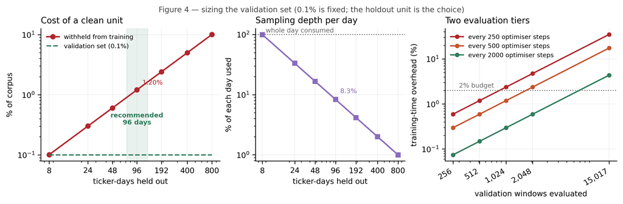

Figure 4 · 90 KB

```
0.1% of the corpus              = 30.1M messages
  as windows @ L=2,000          = 15,017
  as windows @ L=500            = 60,105
full pass over 15,017 windows on 16 GPUs ≈ 5.9 min
512-window fast pass            ≈ 12.2 s = 0.59% overhead at every-500-steps
```

```python
files_total = S["files"]
msgs_total  = S["messages"]
target_msgs = 0.001 * msgs_total
mean_msgs_per_file = msgs_total / files_total

# candidate designs: hold out K whole ticker-days, subsample windows inside them
Ks = np.array([8, 24, 48, 96, 192, 400, 800])
holdout_cost = Ks / files_total * 100                      # % of corpus removed from training
frac_of_file = target_msgs / (Ks * mean_msgs_per_file) * 100   # % of each held-out day actually used

fig, ax = plt.subplots(1, 3, figsize=(9.6, 2.9), layout="constrained",
                       gridspec_kw={"width_ratios": [1.2, 1.0, 1.15]})

a = ax[0]
a.plot(Ks, holdout_cost, "o-", color=C["warn"], lw=1.6, ms=5, label="withheld from training")
a.plot(Ks, np.full_like(Ks, 0.1, dtype=float), "--", color=C["ok"], lw=1.4,
       label="validation set (0.1%)")
a.set_xscale("log"); a.set_xticks(Ks); a.set_xticklabels([str(k) for k in Ks])
a.set_xlabel("ticker-days held out"); a.set_ylabel("% of corpus")
a.annotate("1.20%", (96, holdout_cost[list(Ks).index(96)]), xytext=(6, 6),
           textcoords="offset points", fontsize=7.3, color=C["warn"])
a.axvspan(72, 130, color=C["ok"], alpha=0.10)
a.annotate("recommended\n96 days", (96, 0.32), ha="center", fontsize=7.4, color=C["ok"], fontweight="bold")
a.legend(frameon=False, loc="upper left", fontsize=7.0); a.set_yscale("log")
a.set_title("Cost of a clean unit", loc="left")

a = ax[1]
a.plot(Ks, frac_of_file, "s-", color=C["accent"], lw=1.6, ms=5)
a.axhline(100, color=C["grey"], ls=":", lw=1)
a.text(9, 108, "whole day consumed", fontsize=7.2, color=C["grey"])
a.set_xscale("log"); a.set_yscale("log")
a.set_xticks(Ks); a.set_xticklabels([str(k) for k in Ks])
a.set_xlabel("ticker-days held out"); a.set_ylabel("% of each day used")
a.annotate(f"{frac_of_file[list(Ks).index(96)]:.1f}%", (96, frac_of_file[list(Ks).index(96)]),
           xytext=(5, 7), textcoords="offset points", fontsize=7.5, color=C["accent"])
a.set_title("Sampling depth per day", loc="left")

# evaluation cost
a = ax[2]
s_micro_base = M["ctx2k_training_arms"]["arms"][0]["s_per_micro_step"]
s_micro_hyb  = M["ctx2k_training_arms"]["arms"][1]["s_per_micro_step"]
gpus = 16
n_full = round(S["windows"]["2000"] * 0.001)
sizes = np.array([256, 512, 1024, 2048, n_full])
# forward-only ≈ 0.417/0.900 of the train step time, from Figure 2's two curves
fwd_ratio = M["memory_scaling"]["forward_only"]["s_per_call"][2] / M["memory_scaling"]["forward_backward"]["s_per_call"][2]
eval_s = sizes / gpus * s_micro_hyb * fwd_ratio
opt_step_s = s_micro_hyb * 5     # K=5 at 4 nodes
for every, col, ls in [(250, C["warn"], "-"), (500, C["hyb"], "-"), (2000, C["ok"], "-")]:
    a.plot(sizes, eval_s / (every * opt_step_s) * 100, ls, color=col, marker="o", ms=4,
           lw=1.5, label=f"every {every} optimiser steps")
a.axhline(2, color=C["grey"], ls=":", lw=1); a.text(300, 2.3, "2% budget", fontsize=7.2, color=C["grey"])
a.set_xscale("log"); a.set_yscale("log")
a.set_xticks(sizes); a.set_xticklabels([f"{s:,}" for s in sizes], rotation=30, ha="right")
a.set_xlabel("validation windows evaluated"); a.set_ylabel("training-time overhead (%)")
a.legend(frameon=False, fontsize=7); a.set_title("Two evaluation tiers", loc="left")

fig.suptitle("Figure 4 — sizing the validation set (0.1% is fixed; the holdout unit is the choice)",
             y=1.04, fontsize=8.5, color="#444")
show(fig, "Figure 4")

print(f"0.1% of the corpus              = {target_msgs/1e6:,.1f}M messages")
print(f"  as windows @ L=2,000          = {n_full:,}")
print(f"  as windows @ L=500            = {round(S['windows']['500']*0.001):,}")
print(f"full pass over {n_full:,} windows on 16 GPUs ≈ {n_full/gpus*s_micro_hyb*fwd_ratio/60:.1f} min")
print(f"512-window fast pass            ≈ {512/gpus*s_micro_hyb*fwd_ratio:.1f} s "
      f"= {512/gpus*s_micro_hyb*fwd_ratio/(500*opt_step_s)*100:.2f}% overhead at every-500-steps")
```

### The design

[output not shown]

### What has to be built

1. `build_valset_8stock.py` — pick the 96 ticker-days from the shard indices with a fixed seed, emit `windows_L{500,1000,2000,4000}.npy`, a manifest with per-file SHA-256, and the exclusion list.
2. A **training-side exclusion**: the sampler must skip those 96 files. Today `VAL_SPLIT=0.0` means the train dataset is the whole corpus, so the exclusion is new code, not a flag. This is the one place where getting it wrong is silent and fatal to the result.
3. A validation callback: `VAL_EVERY` in optimiser steps, `valset_fast` inline, `valset_full` at checkpoints.
4. A guard test that fails if any training window overlaps any validation file.

## 5. Compute efficiency — the honest number

The 30% recollection is most likely the number **18.7%** being remembered as a result. It is not a result — it is the *same* 9.4% run divided by a different denominator.

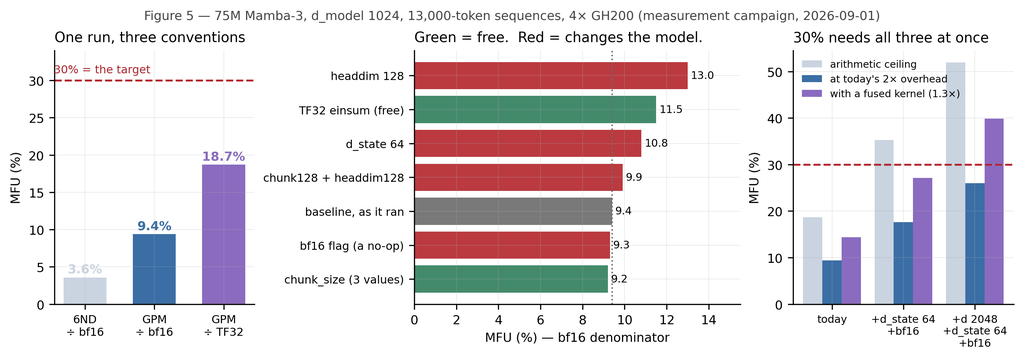

Figure 5 · 78 KB

```python
ref = M["mfu_reference_75m"]
arms = M["ctx2k_training_arms"]
peak_bf16 = M["ctx2k_training_arms"]["peak_bf16_tflops_per_gpu"]
peak_tf32 = M["ctx2k_training_arms"]["peak_tf32_tflops_per_gpu"]

fig, ax = plt.subplots(1, 3, figsize=(9.6, 3.1), layout="constrained",
                       gridspec_kw={"width_ratios": [0.95, 1.55, 1.05]})

# (a) the denominator story
a = ax[0]
bars = [("6ND\n÷ bf16", 9.4/2.63, C["light"]),
        ("GPM\n÷ bf16", ref["baseline_mfu_pct_bf16_denominator"], C["base"]),
        ("GPM\n÷ TF32", ref["baseline_mfu_pct_tf32_denominator"], C["accent"])]
a.bar(range(3), [b[1] for b in bars], color=[b[2] for b in bars], width=0.62)
for i, b in enumerate(bars):
    a.text(i, b[1]+0.6, f"{b[1]:.1f}%", ha="center", fontsize=8.5, fontweight="bold", color=b[2])
a.axhline(30, color=C["warn"], lw=1.3, ls="--")
a.text(-0.45, 31, "30% = the target", ha="left", color=C["warn"], fontsize=7.6)
a.set_xticks(range(3)); a.set_xticklabels([b[0] for b in bars], fontsize=7.6)
a.set_ylabel("MFU (%)"); a.set_ylim(0, 34)
a.set_title("One run, three conventions", loc="left")

# (b) levers
a = ax[1]
lv = [l for l in ref["levers"] if l["mfu_pct"] is not None]
base_mfu = ref["baseline_mfu_pct_bf16_denominator"]
SHORT = {"MAMBA3_CONTRACTION_PRECISION=default (TF32 einsum)": "TF32 einsum (free)",
         "headdim 64 -> 128": "headdim 128",
         "d_state 128 -> 64": "d_state 64",
         "chunk_size 64 / 128 / 256": "chunk_size (3 values)",
         "bf16 flag": "bf16 flag (a no-op)",
         "chunk128 + headdim128 together": "chunk128 + headdim128"}
names = ["baseline, as it ran"] + [SHORT[l["lever"]] for l in lv]
vals  = [base_mfu] + [l["mfu_pct"] for l in lv]
chg   = [False] + [l["changes_model"] for l in lv]
cols  = [C["grey"]] + [C["warn"] if c else C["ok"] for c in chg[1:]]
o = np.argsort(vals)
a.barh(range(len(vals)), [vals[i] for i in o], color=[cols[i] for i in o], alpha=0.9)
a.set_yticks(range(len(vals)))
a.set_yticklabels([names[i] for i in o], fontsize=7.6)
for j, i in enumerate(o):
    a.text(vals[i]+0.15, j, f"{vals[i]:.1f}", va="center", fontsize=7.2)
a.axvline(base_mfu, color=C["grey"], ls=":", lw=1)
a.set_xlabel("MFU (%) — bf16 denominator"); a.set_xlim(0, 15.5)
a.set_title("Green = free.  Red = changes the model.", loc="left")

# (c) path to 30
a = ax[2]
p = ref["path_to_30"]
xb = np.arange(len(p)); w = 0.27
a.bar(xb-w, [q["ceiling_pct"] for q in p], w, color=C["light"], label="arithmetic ceiling")
a.bar(xb,   [q["achieved_at_2x_overhead_pct"] for q in p], w, color=C["base"], label="at today's 2× overhead")
a.bar(xb+w, [q["achieved_with_fused_1p3x_pct"] for q in p], w, color=C["accent"], label="with a fused kernel (1.3×)")
a.axhline(30, color=C["warn"], lw=1.3, ls="--")
a.set_xticks(xb)
a.set_xticklabels(["today", "+d_state 64\n+bf16", "+d 2048\n+d_state 64\n+bf16"], fontsize=7.2)
a.set_ylabel("MFU (%)"); a.legend(frameon=False, fontsize=6.8, loc="upper left")
a.set_title("30% needs all three at once", loc="left")

fig.suptitle("Figure 5 — 75M Mamba-3, d_model 1024, 13,000-token sequences, 4× GH200 "
             "(measurement campaign, 2026-09-01)", y=1.05, fontsize=8.5, color="#444")
show(fig, "Figure 5")
```

### What the three panels say

**Left.** The 9.4% and the 18.7% are the same run. The numerator is `3ND × correction` where the correction is a GPM tensor-pipe measurement; the denominator in the first two bars is the bf16 tensor-core peak of 989 TFLOPS. But **the model never executes a bf16 kernel** — `args.dtype` has zero consumers anywhere in `src/`, and the GPM FP16 pipe counter reads exactly 0.0%. Dividing by the TF32 peak instead, which is what the hardware is actually doing, gives 18.7% for the identical run. That is a relabelling, not an optimisation, and it is almost certainly where "about 30%" came from.

**Middle.** Only one lever is both effective and free: `MAMBA3_CONTRACTION_PRECISION=default`, worth +24% wall-clock and reproduced twice. Everything else is either zero (`chunk_size` — three settings inside noise), negative (`d_state` 64 is *slower* than TF32 alone; `chunk128 + headdim128` together are worse than either alone), a no-op (the bf16 flag), or changes the model (`headdim` 128 is the largest single win at +41%, but it moves the parameter count and the head structure).

### Why this model is a worse case than the 75M reference

The hardware correction factor is width-dependent and was measured per width. At `d_model=640` it is **3.09**; at 1024 it is **2.63**. A higher correction means more of the work is non-matmul elementwise SSD arithmetic that runs on CUDA cores at 67 TFLOPS rather than on tensor cores at 494. **Width is the real MFU lever, and 640 is on the wrong side of it.**

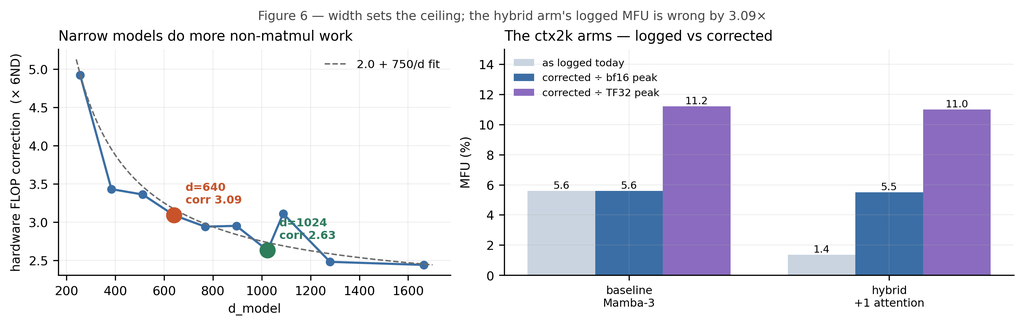

Figure 6 · 69 KB

```
baseline pure mamba3               logged  5.60%   corrected/bf16  5.60%   corrected/TF32 11.21%
hybrid mamba3 + 1 attention        logged  1.36%   corrected/bf16  5.49%   corrected/TF32 11.00%
```

```python
ct = {int(k): v for k, v in ref["correction_table"].items()}
ws = sorted(ct)
fig, ax = plt.subplots(1, 2, figsize=(9.6, 2.8), layout="constrained", gridspec_kw={"width_ratios": [1, 1.3]})

a = ax[0]
a.plot(ws, [ct[w] for w in ws], "o-", color=C["base"], lw=1.5, ms=5)
for w in (640, 1024):
    a.plot([w], [ct[w]], "o", color=C["hyb"] if w == 640 else C["ok"], ms=10, zorder=5)
    a.annotate(f"d={w}\ncorr {ct[w]:.2f}", (w, ct[w]), xytext=(8, 8), textcoords="offset points",
               fontsize=7.6, color=C["hyb"] if w == 640 else C["ok"], fontweight="bold")
wf = np.linspace(240, 1700, 100)
a.plot(wf, 2.0 + 750/wf, "--", color=C["grey"], lw=1, label="2.0 + 750/d fit")
a.set_xlabel("d_model"); a.set_ylabel("hardware FLOP correction  (× 6ND)")
a.legend(frameon=False); a.set_title("Narrow models do more non-matmul work", loc="left")

# measured MFU of the two ctx2k arms, both conventions
a = ax[1]
tps = 416000
rows = []
for arm in arms["arms"]:
    corr_true = ct[640]
    f6nd = 6 * arm["params"] * tps
    fl = corr_true * f6nd
    if "hybrid" in arm["name"]:
        L = 2000*26
        attn = 8 * (2 * L*L * 640) * 3      # 8 sequences, causal fwd 2L^2d, backward ~2x
        fl += attn
    ach = fl / arm["s_per_micro_step"] / 1e12
    rows.append((arm["name"], ach/(8*peak_bf16)*100, ach/(8*peak_tf32)*100,
                 arm["tflops_per_step_logged"]/arm["s_per_micro_step"]/(8*peak_bf16)*100))
xb = np.arange(2); w = 0.26
a.bar(xb-w, [r[3] for r in rows], w, color=C["light"], label="as logged today")
a.bar(xb,   [r[1] for r in rows], w, color=C["base"],  label="corrected ÷ bf16 peak")
a.bar(xb+w, [r[2] for r in rows], w, color=C["accent"],label="corrected ÷ TF32 peak")
for i, r in enumerate(rows):
    for dx, v in [(-w, r[3]), (0, r[1]), (w, r[2])]:
        a.text(i+dx, v+0.15, f"{v:.1f}", ha="center", fontsize=7.0)
a.set_xticks(xb); a.set_xticklabels(["baseline\nMamba-3", "hybrid\n+1 attention"], fontsize=7.6)
a.set_ylabel("MFU (%)"); a.legend(frameon=False, fontsize=7, loc="upper left")
a.set_ylim(0, 15)
a.set_title("The ctx2k arms — logged vs corrected", loc="left")

fig.suptitle("Figure 6 — width sets the ceiling; the hybrid arm's logged MFU is wrong by 3.09×",
             y=1.05, fontsize=8.5, color="#444")
show(fig, "Figure 6")

for r in rows:
    print(f"{r[0]:34s} logged {r[3]:5.2f}%   corrected/bf16 {r[1]:5.2f}%   corrected/TF32 {r[2]:5.2f}%")
```

### The efficiency plan for this run

| # | action | expected | changes the model? |
| --- | --- | --- | --- |
| 1 | fix the correction gate to key on `architecture`, and add the attention layer's L² term for hybrids | correct numbers, no speed change | no |
| 2 | set `MAMBA3_CONTRACTION_PRECISION=default` and re-measure at d=640, L=52,000 | +24% is the d=1024/L=13,000 reading; **it must be re-measured here** — the arithmetic mix at 4× the length is different | no (numerics only) |
| 3 | report MFU against the TF32 peak, stating the convention on every figure | 5.6% → 11.2% by relabelling | no |
| 4 | one smoke run with `LOG_GRAD_NORMS=1` + throughput logging to fix the real step time at 4 nodes | sets the wall-clock estimate below | no |
| 5 | **not** in this run: `headdim` 128, `d_state` 64, bf16, fused kernels | these are the only route past ~12%, and each one breaks comparability with every existing checkpoint | yes |

The honest summary to carry into the run card: **expect 11–12% MFU against the TF32 peak after step 2, and about 5.5–6% against the bf16 peak.** Anyone quoting 30% for this model is quoting a target.

## 6. The run

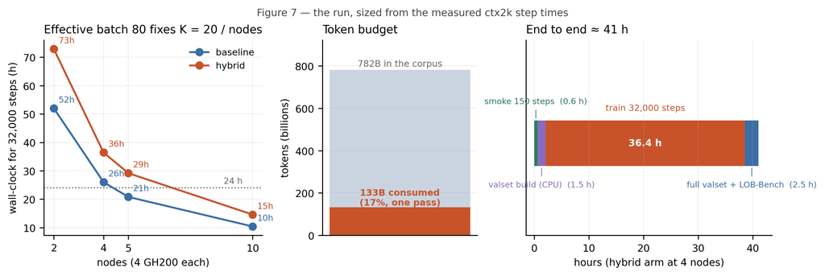

Figure 7 · 72 KB

```
baseline  4 nodes  K= 5  opt step  2.92s  32,000 steps =  26.0 h
baseline  5 nodes  K= 4  opt step  2.34s  32,000 steps =  20.8 h
hybrid    4 nodes  K= 5  opt step  4.10s  32,000 steps =  36.4 h
hybrid    5 nodes  K= 4  opt step  3.28s  32,000 steps =  29.2 h
```

```python
rec = M["recipe"]
s_base = arms["arms"][0]["s_per_micro_step"]; s_hyb = arms["arms"][1]["s_per_micro_step"]
EFF = rec["effective_batch_sequences"]; STEPS = rec["cosine_steps"]

fig, ax = plt.subplots(1, 3, figsize=(9.6, 2.95), layout="constrained",
                       gridspec_kw={"width_ratios": [1.2, 0.85, 1.35]})

a = ax[0]
nodes = np.array([2, 4, 5, 8, 10])
K = EFF / (1 * 4 * nodes)
ok = np.isclose(K, np.round(K))
for s, col, lab in [(s_base, C["base"], "baseline"), (s_hyb, C["hyb"], "hybrid")]:
    hrs = STEPS * K * s / 3600
    a.plot(nodes[ok], hrs[ok], "o-", color=col, lw=1.6, ms=6, label=lab)
    for n_, h_ in zip(nodes[ok], hrs[ok]):
        a.annotate(f"{h_:.0f}h", (n_, h_), xytext=(4, 5), textcoords="offset points",
                   fontsize=7.2, color=col)
a.axhline(24, color=C["grey"], ls=":", lw=1); a.text(9.6, 25.5, "24 h", ha="right", fontsize=7.2, color=C["grey"])
a.set_xlabel("nodes (4 GH200 each)"); a.set_ylabel("wall-clock for 32,000 steps (h)")
a.set_xticks(nodes[ok]); a.legend(frameon=False)
a.set_title("Effective batch 80 fixes K = 20 / nodes", loc="left")

a = ax[1]
tok_run = STEPS * EFF * 2000 * 26 / 1e9
tok_corp = S["messages"] * 26 / 1e9
a.bar([0], [tok_corp], color=C["light"], width=0.5)
a.bar([0], [tok_run], color=C["hyb"], width=0.5)
a.text(0, tok_corp*1.02, f"{tok_corp:,.0f}B in the corpus", ha="center", fontsize=7.6, color=C["grey"])
a.text(0, tok_run*1.06, f"{tok_run:,.0f}B consumed\n({tok_run/tok_corp*100:.0f}%, one pass)",
       ha="center", fontsize=7.6, color=C["hyb"], fontweight="bold")
a.set_xticks([]); a.set_ylabel("tokens (billions)"); a.set_ylim(0, tok_corp*1.18)
a.set_title("Token budget", loc="left")

a = ax[2]
stages = ["smoke 150 steps", "valset build (CPU)", "train 32,000 steps", "full valset + LOB-Bench"]
dur    = [0.6, 1.5, STEPS*5*s_hyb/3600, 2.5]
colr   = [C["ok"], C["accent"], C["hyb"], C["base"]]
left = 0
for j, (st, d_, c_) in enumerate(zip(stages, dur, colr)):
    a.barh([0], [d_], left=left, color=c_, height=0.42)
    if d_ > 6:
        a.text(left + d_/2, 0, f"{d_:.1f} h", ha="center", va="center",
               fontsize=8, color="white", fontweight="bold")
        a.text(left + d_/2, 0.30, st, ha="center", fontsize=7.4, color=c_)
    else:
        yy = 0.30 if j % 2 == 0 else -0.34
        a.annotate(f"{st}  ({d_:.1f} h)", (left + d_/2, 0.21 if yy > 0 else -0.21),
                   xytext=(0, 16 if yy > 0 else -16), textcoords="offset points",
                   ha="center", va="center" , fontsize=7.0, color=c_,
                   arrowprops=dict(arrowstyle="-", color=c_, lw=0.6))
    left += d_
a.set_yticks([]); a.set_xlabel("hours (hybrid arm at 4 nodes)")
a.set_xlim(-1.5, left*1.06); a.set_ylim(-0.85, 0.95)
a.set_title(f"End to end ≈ {left:.0f} h", loc="left")

fig.suptitle("Figure 7 — the run, sized from the measured ctx2k step times",
             y=1.05, fontsize=8.5, color="#444")
show(fig, "Figure 7")

for nm, s in [("baseline", s_base), ("hybrid", s_hyb)]:
    for n_ in [4, 5]:
        k = EFF // (4*n_)
        print(f"{nm:9s} {n_} nodes  K={k:2d}  opt step {k*s:5.2f}s  "
              f"32,000 steps = {STEPS*k*s/3600:5.1f} h")
```

```python
r = M["recipe"]; a0 = arms["arms"]
card = f'''
**Table 3 — the run card**

| field | value |
|---|---|
| architecture | `{r['architecture']}` — Mamba-3 trunk, one global-attention layer at position 3 (Nemotron rule for L=6), NoPE |
| width / depth | d_model {r['d_model']}, {r['n_layers']} fused layers, blocks {r['blocks']} |
| Mamba-3 | d_state {r['mamba3']['d_state']}, expand {r['mamba3']['expand']}, headdim {r['mamba3']['headdim']}, chunk {r['mamba3']['chunk_size']}, RoPE fraction {r['mamba3']['rope_fraction']} |
| attention | {r['attention']['heads']} heads × head_dim {r['attention']['head_dim']}, flash, no positional encoding, d_ff {r['attention']['d_ff']} |
| parameters | {a0[1]['params']:,} (baseline {a0[0]['params']:,}, +5.4%) |
| **context** | **2,000 messages = 52,000 tokens** (fitted wall 2,050 at MEM_FRACTION 0.85) |
| tokenisation | {r['token_mode']}, vocab {r['vocab_size']}, {r['tokens_per_message']} tokens/message |
| data | {len(r['data']['tickers'])} tickers × {r['data']['months']} months, {r['data']['range']} |
| optimiser | {r['optimizer']['config']}, muon lr {r['optimizer']['muon_lr']}, ssm lr {r['optimizer']['ssm_lr_base']}, wd {r['optimizer']['weight_decay']}, {r['optimizer']['warmup']} |
| effective batch | {r['effective_batch_sequences']} sequences (declared; K is derived as 20 / nodes) |
| steps | {r['cosine_steps']:,} optimiser steps = {r['cosine_steps']*r['effective_batch_sequences']*2000*26/1e9:,.0f}B tokens = 17.0% of one epoch |
| micro-batch | 1 sequence per GPU (forced: 70.9 GB peak at 52,000 tokens) |
| MEM_FRACTION | 0.85 |
| `REMAT` | **0** — decided 2026-09-04, and a no-op on the recurrent trunk in any case |
| checkpoint / logging | `CHECKPOINT_EVERY=auto` (15 min), wandb every 1 min, `LOG_GRAD_NORMS=1`, `LOG_EVERY=250` |
| efficiency | `MAMBA3_CONTRACTION_PRECISION=default`; MFU reported against the TF32 peak with the convention stated |
| validation | `valset_fast` (512 windows) every 500 steps; `valset_full` (15,017) every 4,000 steps and at the end |
| control arm | the pure Mamba-3 baseline, same seed, same effective batch, same steps — the only difference is the attention layer |
'''
display(Markdown(card))
```

**Table 3 — the run card**

| field | value |
| --- | --- |
| architecture | `hybrid_mamba3` — Mamba-3 trunk, one global-attention layer at position 3 (Nemotron rule for L=6), NoPE |
| width / depth | d_model 640, 6 fused layers, blocks 20 |
| Mamba-3 | d_state 128, expand 2, headdim 64, chunk 64, RoPE fraction 0.5 |
| attention | 10 heads × head_dim 64, flash, no positional encoding, d_ff 2560 |
| parameters | 35,435,423 (baseline 33,610,439, +5.4%) |
| **context** | **2,000 messages = 52,000 tokens** (fitted wall 2,050 at MEM_FRACTION 0.85) |
| tokenisation | 26tok, vocab 2112, 26 tokens/message |
| data | 8 tickers × 48 months, 2022-01-01..2025-12-31 |
| optimiser | muon, muon lr 0.01, ssm lr 0.0008, wd 0.005, 1% then cosine |
| effective batch | 80 sequences (declared; K is derived as 20 / nodes) |
| steps | 32,000 optimiser steps = 133B tokens = 17.0% of one epoch |
| micro-batch | 1 sequence per GPU (forced: 70.9 GB peak at 52,000 tokens) |
| MEM_FRACTION | 0.85 |
| `REMAT` | **0** — decided 2026-09-04, and a no-op on the recurrent trunk in any case |
| checkpoint / logging | `CHECKPOINT_EVERY=auto` (15 min), wandb every 1 min, `LOG_GRAD_NORMS=1`, `LOG_EVERY=250` |
| efficiency | `MAMBA3_CONTRACTION_PRECISION=default`; MFU reported against the TF32 peak with the convention stated |
| validation | `valset_fast` (512 windows) every 500 steps; `valset_full` (15,017) every 4,000 steps and at the end |
| control arm | the pure Mamba-3 baseline, same seed, same effective batch, same steps — the only difference is the attention layer |

### Order of work, and what stops it

1. **Fix the FLOP-accounting gate** (`train.py:376`) — one line. Without it every efficiency number in the run is wrong by 3.09× for one arm only.
2. **Build the validation set** — CPU only, reads the 48 shard indices. Emits the window lists at all four context lengths plus a manifest with SHA-256, so the same set is reusable when the context axis is revisited.
3. **Wire the exclusion and the validation callback.** `VAL_SPLIT=0.0` means there is no existing code path to piggyback on. **This is the step where a silent mistake is fatal**: if the 96 held-out files are not actually excluded from the sampler, the validation curve measures nothing and nothing will report an error.
4. **Guard test** — assert zero file overlap between the training sampler and the validation window list, and assert the validation set's SHA-256 at load time.
5. **Smoke, 150 steps**, checking four things: 48 shards mount, the checkpoint round-trips with the new parameter tree, `len(dataset)` matches the count in Table 2 minus the 96 held-out files, and the step time at 4 nodes.
6. **Both arms**, 32,000 steps, from the same seed. The baseline arm is not optional — every claim in Figure 1 is a paired claim.
7. **Evaluate**: full validation set, LOB-Bench on the frozen 3,136-sequence pool, reference-recall by age.

### Two things this plan deliberately does not do

**It does not go to 4,000 messages.** The memory arithmetic says 134-142 GB against an 85.5 GB card, and remat, the one cheap lever that would have fixed it, is ruled out by decision (2026-09-04) on top of being a no-op on the recurrent trunk today. The only remaining route is sequence parallelism, which is a separate piece of work with its own measurement campaign.

## 7. Where this goes: `oxford-lob` on Hugging Face

The organisation `oxford-lob` (BOLD-Quant-Team, 3 members) currently holds **zero** repositories. Proposed: one **dataset** repo whose README is the page this information lives on.

```
huggingface.co/datasets/oxford-lob/lob-8stock-2022-2025
├── README.md                     ← the repo page: corpus tables, valset spec, provenance
├── corpus/
│   ├── dataset_stats_8stock.json     per-ticker, per-month, windows at each L
│   └── count_windows_from_shard_indices.py
├── valset_v1/
│   ├── holdout_files.json            the 96 ticker-days, with the selection seed
│   ├── windows_L500.npy              (N,2) int64 (file_idx, seq_start)
│   ├── windows_L1000.npy
│   ├── windows_L2000.npy
│   ├── windows_L4000.npy
│   ├── manifest.json                 sizes, SHA-256, evaluation budget
│   └── SHA256SUMS
└── notebooks/
    └── hybrid_longctx_8stock_training_plan.ipynb
```

Two constraints carried over from the existing Hugging Face work on this project. The raw LOBSTER-derived message data **cannot** be published — the repo must stay private and hold only indices, counts and window offsets, never message content. And a free-tier account rate-limits at roughly 125 commits per 35 minutes, so the upload is a single `upload-large-folder` call rather than a loop.

**Nothing is pushed to Hugging Face until this plan is confirmed.**

### Open decisions

| # | decision | recommendation |
| --- | --- | --- |
| 1 | context length: 2,000 now, or wire remat first and aim at 4,000? | **settled 2026-09-04: 2,000 messages, no remat.** Both launch scripts annotated at the `REMAT=0` line |
| 2 | holdout unit: 96 ticker-days (1.2% withheld) vs 8 ticker-days (0.1% withheld, but only 8 days of diversity) | **96.** 1.2% of a corpus we consume 17% of is not a cost |
| 3 | run the baseline arm as well, doubling the compute? | **yes.** Figure 1 is a paired claim; an unpaired hybrid number cannot be read |
| 4 | efficiency: free levers only, or also `headdim` 128 (+41%)? | **free levers only** in this run; `headdim` 128 as a separate, explicitly-labelled architecture experiment |
| 5 | Hugging Face repo type | **dataset** repo, private, README as the page |